# Scratch pad for Colinearity Analysis

Javier Matias-Cabrera, javierm4

```r
library(jtools)

source("load_dataset.r")
source("transformations.r")
source("plots.r")
```

### Introduction

For this study, we will perform some exploratory data analysis to explain how the effect of a continous predictor on the response varies across different treatment groups (categorical predictor). Namely, we’ll test:

$H_0: \beta_{j,LivArea:Neighborhood} = 0, \forall j \text{ - The mean price per square foot of a house is the same for every neighborhood j }$

$H_1: \beta_{j,LivArea:Neighborhood} \neq 0, \forall j \text{ - At least one neighborhood j has a different mean price per square foot }$

We will also attempt to infer which neighborhoods place the highest monetary value on living area and determine whether the living area is collinear with other predictors.

### Methods

We will begin by loading the housing data stored in `AmesHousing.csv`. We will also define a convenience function `splitDataset` that will randomly split the data into two data sets: *“train”* and *“test”*.

```r
splitDataset = function(data) {
  training = createDataPartition(data$SalePrice, times=1, p=0.80, list=FALSE)
  return(list(train=data[training,], test=data[-training,]))
}

housing_data = read_dataset("../data/AmesHousing.csv")

splits = splitDataset(housing_data)
training_data = splits$train
test_data = splits$test
```

Now we can begin our exploratory data analysis. To examine the relationship between `Neighborhood` and `SalePrice`, we will perform a simple one-way ANOVA to determine whether belonging to different neighborhoods has any effect on `SalePrice` at all.

```r
neighborhood_oneway_anova = aov(SalePrice ~ Neighborhood, data=housing_data)
neigh_oneway_anova_summary = summary(neighborhood_oneway_anova)
```

A simple linear model would allow us to infer whether the General Living Area (`Gr.Liv.Area`) of a house has any relationship with `SalePrice`.

```r
livarea_model = lm(SalePrice ~ Gr.Liv.Area, data=housing_data)
livarea_model_summary = summary(livarea_model)
```

And, in order to infer whether or not a house’s living area is more expensive in some neighborhoods than others, we’ll perform Analysis of Co-Variance (ANCOVA) by including an interaction term between the continous variable `Gr.Liv.Area` and the categorical variable `Neighborhood`. If the slopes of `Gr.Liv.Area` are different (not parallel) for different neighborhoods, then we would notice a strong interaction between the two predictors.

```r
neigh_livarea_interaction_model = lm(SalePrice ~ Gr.Liv.Area*Neighborhood, data=housing_data)
neigh_livarea_anova = anova(neigh_livarea_interaction_model)
p_value_neigh_livarea_interact =anova(neigh_livarea_interaction_model)[3,5]
```

We will also estimate actual slopes of the lines of `SalePrice` vs. `Gr.Liv.Area` for different neighborhoods to examine any differences.

```r
livarea_slopes_raw = sim_slopes(neigh_livarea_interaction_model, pred=Gr.Liv.Area, modx=Neighborhood,
                        johnson_neyman = FALSE,centered= "none", confint=T)

livarea_slopes = data.frame(livarea_slopes_raw$slopes[,1:5],stringsAsFactors=FALSE)
livarea_slopes[,2:5] = sapply(livarea_slopes[,2:5], as.double)
livarea_slopes[,2:5] = sapply(livarea_slopes[,2:5], signif, digits=4)

colnames(livarea_slopes)[1] = "Neighborhood"
colnames(livarea_slopes)[3] = "Std. Err."
colnames(livarea_slopes)[4] = "2.5%"
colnames(livarea_slopes)[5] = "97.5%"
```

Lastly, in order to determine whether the effect of `Gr.Liv.Area` on `SalePrice` is not explained by other predictors, we’ll calculate the partial correlation coefficient between them with the effect of all other predictors removed.

### Results

#### Neighborhood Effect on Living Area Price

From out first ANOVA of `Neighborhood` and `SalePrice`, it can easily be seen that the neighborhood had a significant effect on the price. We can also see this graphically using a box-plot.

```r
neigh_oneway_anova_summary
```

```
##                Df    Sum Sq   Mean Sq F value Pr(>F)
## Neighborhood   25 7.173e+12 2.869e+11   157.9 <2e-16 ***
## Residuals    2815 5.116e+12 1.818e+09
## ---
## Signif. codes:  0 '***' 0.001 '**' 0.01 '*' 0.05 '.' 0.1 ' ' 1
```

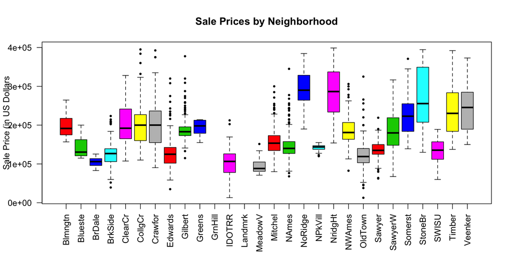

```r
boxplot(SalePrice ~ Neighborhood, data = housing_data,las=2, col=2:8, pch=20, cex=.7,
        main="Sale Prices by Neighborhood",
        ylab="Sale Price (in US Dollars")
```

Similarly, it is easily shown that `Gr.Liv.Area` has an effect on `SalePrice`.

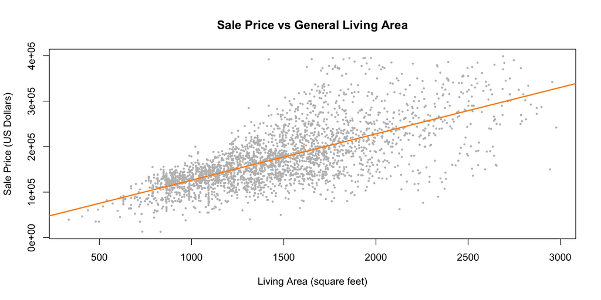

```r
plot(SalePrice ~ Gr.Liv.Area, data = housing_data,
     xlab = "Living Area (square feet)",
     ylab = "Sale Price (US Dollars)",
     main = "Sale Price vs General Living Area",
     pch  = 20,
     cex  = .5,
     col  = "grey")
abline(livarea_model, col="darkorange", lwd=2)
```

However, we also observe that the interaction model between `Neighborhood` and `Gr.Liv.Area` yielded a near-zero p-value of 5.57710^{-35}. This **suggests a significant interaction between the two predictors** when predicting `SalePrice`.

```r
signif(p_value_neigh_livarea_interact,4)
```

```
## [1] 5.577e-35
```

```r
print(neigh_livarea_anova[-4,], signif.stars=FALSE)
```

```
## Analysis of Variance Table
##
## Response: SalePrice
##                          Df     Sum Sq    Mean Sq   F value    Pr(>F)
## Gr.Liv.Area               1 5.8694e+12 5.8694e+12 5667.3853 < 2.2e-16
## Neighborhood             25 3.2847e+12 1.3139e+11  126.8647 < 2.2e-16
## Gr.Liv.Area:Neighborhood 25 2.4677e+11 9.8706e+09    9.5309 < 2.2e-16
```

Because of this, we obtain different slopes for `Gr.Liv.Area` depending on `Neighborhood`. Each of the slope estimates are the sum of the `Gr.Liv.Area` coefficient and its interaction term with the corresponding `Neighborhood` factor dummy variable. As with all estimates, we can calculate a mean and a confidence interval.

[figure not shown]

```r
## Get the top 5 neighborhoods with the most houses
ordered_neigh = order(-table(housing_data$Neighborhood))

interact_plot(neigh_livarea_interaction_model, pred=Gr.Liv.Area,
              modx=Neighborhood,color.class="Qual1",
              modxvals = names(table(housing_data$Neighborhood)[ordered_neigh][1:6]),
              x.label="General Living Area (square feet)",
              y.label="Sale Price (US Dollars)") +
  ggtitle("Gr.Liv.Area Slopes of the 5 Neighborhoods with Most Sales" ) +
  theme(plot.title = element_text(hjust = 0.5))
```

```r
kable(livarea_slopes)
```

| Neighborhood | Est. | Std. Err. | 2.5% | 97.5% |
| --- | --- | --- | --- | --- |
| Blmngtn | 130.50 | 40.580 | 50.890 | 210.00 |
| Blueste | -14.07 | 63.910 | -139.400 | 111.20 |
| BrDale | 54.89 | 41.400 | -26.290 | 136.10 |
| BrkSide | 79.61 | 8.586 | 62.780 | 96.45 |
| ClearCr | 59.76 | 13.320 | 33.640 | 85.89 |
| CollgCr | 99.84 | 4.959 | 90.120 | 109.60 |
| Crawfor | 88.83 | 7.939 | 73.270 | 104.40 |
| Edwards | 72.41 | 7.054 | 58.580 | 86.24 |
| Gilbert | 75.01 | 8.575 | 58.200 | 91.83 |
| Greens | 100.00 | 72.880 | -42.860 | 243.00 |
| IDOTRR | 62.57 | 8.384 | 46.130 | 79.01 |
| MeadowV | 37.29 | 16.030 | 5.852 | 68.72 |
| Mitchel | 55.55 | 7.928 | 40.000 | 71.09 |
| NAmes | 53.11 | 4.196 | 44.880 | 61.34 |
| NoRidge | 70.72 | 13.950 | 43.360 | 98.07 |
| NPkVill | 25.16 | 27.510 | -28.790 | 79.11 |
| NridgHt | 114.90 | 7.283 | 100.600 | 129.20 |
| NWAmes | 67.46 | 6.500 | 54.710 | 80.20 |
| OldTown | 46.83 | 4.304 | 38.390 | 55.27 |
| Sawyer | 36.18 | 7.401 | 21.670 | 50.69 |
| SawyerW | 77.76 | 6.395 | 65.220 | 90.30 |
| Somerst | 114.40 | 8.567 | 97.620 | 131.20 |
| StoneBr | 116.40 | 11.610 | 93.590 | 139.10 |
| SWISU | 33.68 | 9.935 | 14.200 | 53.17 |
| Timber | 97.26 | 10.840 | 76.000 | 118.50 |
| Veenker | 27.37 | 12.970 | 1.931 | 52.81 |

### Discussion

#### Relationship between Neighborhood, Sale Price and Other Predictors

Having observed how both `Neighborhood` and `Gr.Liv.Area` interact with each other and influence `SalePrice`, it is important to highlight that it **does not imply a casual relationship** between them. This becomes more evident when we examine the partial correlation coefficient of `Gr.Liv.Area` and `SalePrice` with the effect of all other 78 predictors removed. We observe that its magnitude is less than 0.02.

```r
without_livarea       = lm(SalePrice ~ . -Gr.Liv.Area , data=housing_data)
livarea_collinearity  = lm(Gr.Liv.Area~ . -SalePrice, data=housing_data)
(partial_corr_livarea_saleprice = cor(resid(without_livarea),resid(livarea_collinearity)))
```

```
## [1] -0.01958984
```

Therefore, general living area is collinear with many of the other predictors available in the dataset, and does not independently predict price. We can, however, **reject the null hypothesis** that the average price per square foot of living space is equal for all neighborhoods with a confidence level $\alpha= 0.01$.